# Practical Machine Learning - Course Project

Pablo Cordova

2022-08-06

## Assignement

Using the data sect from [this project](http://groupware.les.inf.puc-rio.br/har), we need to predict if people performed barbell lifts correctly.

## Packages

For this assignment we will use the following packages:

- **Tidyverse**
- **caret**
- **gmb**
- **readr**
- **kableExtra**
- **corrplot**
- **lubridate**
- **fastDummies**

## The data

We have a [training](https://d396qusza40orc.cloudfront.net/predmachlearn/pml-training.csv) and a [test](https://d396qusza40orc.cloudfront.net/predmachlearn/pml-testing.csv) dataset that have been provided with the assignement and loaded.

### Checking and cleaning the data

#### Empty values

We run a few checks on the **training** dataset.

- Empty variables: there was no variable completely empty.
- Empty rows: there are no empty rows.

However, there are **100 variables with 97% of NA values**. We removed them from the training and test datasets (Annex 1 has the complete list of the variables removed)

#### Variables Class

We explore the class of the variables, and we see that only four are not numeric.

| variable | user_name | cvtd_timestamp | new_window | classe |
| --- | --- | --- | --- | --- |

Three of these variables are factors: **user_name**, **new_window**, **classe**. The **cvtd_timestamp** is a time and date. We will apply these modifications in the datasets, i.e. move these variables from character to factor or date and time.

#### Correlation between variables

We first explore the correlation across covariates. In Annex 2, you can find a correlation matrix plot (the higher the intensity of the color, the higher the correlation). We see that the variance of exercises has a high correlation among them (gyros_dumbell_x is correlated with gyros_dumbell_y and gyros_dumbell_z)

#### Relationship between covariates and classe

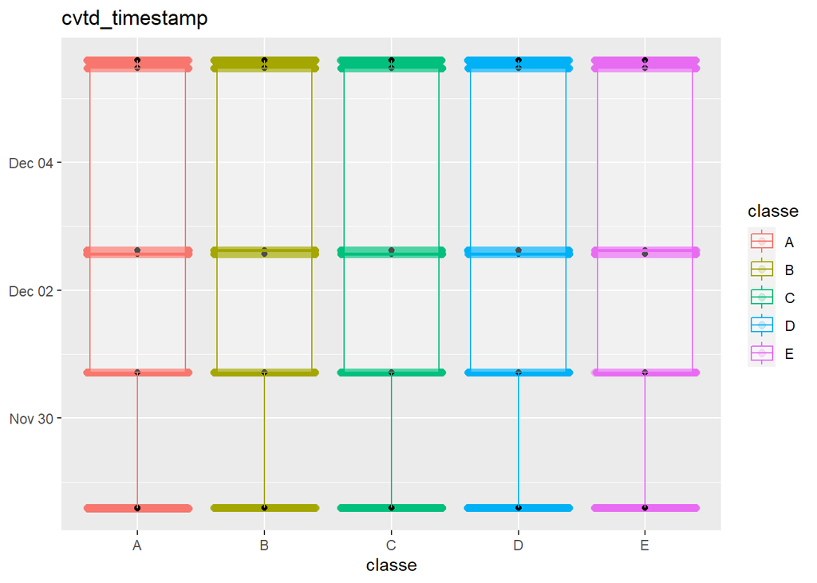

```r
for(i in 1:length(var_list)){

  temp<-training_clean2%>%select(classe,var_list[i])%>%
    ggplot(aes(classe,get(var_list[i]),color=classe))+
  geom_jitter(alpha=0.3,size=2)+geom_point(color="black")+geom_boxplot(alpha=0.3)+
    labs(title=var_list[i])+theme(axis.title.y=element_blank())
  assign(paste0("plot_",var_list[i]),temp)
  invisible(ggsave(paste0(".//plots_raw//plot_",var_list[i],".jpg"),temp))
}
```

#### Removing zero covariates

We check for zero covariates. We see that the variable **new_window** is a near zero var covariate, so we remove it from the dataset.

| var | freqRatio | percentUnique | zeroVar | nzv |
| --- | --- | --- | --- | --- |
| new_window | 47.33005 | 0.0101926 | FALSE | TRUE |

#### Removing the index and the user

Finally, we remove the column **“…1”** - which is just the row index - and the **user_name**.

#### Final Datasets

Finally, after checking, we see that the **classe** variable is not present in the testing dataset, it has been replaced with a variable **problem_id**

We end with datasets of the following dimensions

## Cross Validation

For cross-validation, we will split the data into two datasets according to the following percentages:

- Training dataset: 70%.
- Testing dataset: 30%.

To avoid any confusion, we rename the original **testing dataset** (the one with 20 observations) to **final validation dataset**

The code to split the data set is below:

```r
#we create the training data set with 60% of the observations
split1<-createDataPartition(y=training_clean5$classe,p=0.7,list=FALSE)
train<-training_clean5[split1,]
test<-training_clean5[-split1,]
```

## The models

We will use the following models:

- **Trees**
- **Random forest**
- **Gradient Boosted Trees**
- **Model based prediction**

For each of the models, we generated predicted values and generate the confusion matrix.

```r
# we create the model
set.seed(1234)
control <- trainControl(method="cv", number=3, verboseIter=F)

## decision tree
mod_trees <- train(classe~., data=train, method="rpart",
                   trControl = control, tuneLength = 5)

pred_trees<-predict(mod_trees,test)
conf_trees<-confusionMatrix(pred_trees,factor(test$classe))

## random forest
mod_rf <- train(classe~., data=train, method="rf",
                   trControl = control, tuneLength = 5)

pred_rf<-predict(mod_rf,test)
conf_rf<-confusionMatrix(pred_rf,factor(test$classe))


## Boosting with trees
mod_gbm <- train(classe~., data=train, method="gbm",
                   trControl = control, tuneLength = 5,verbose=FALSE)

pred_gbm<-predict(mod_gbm,test)
conf_gbm<-confusionMatrix(pred_gbm,factor(test$classe))


##model based prediction
mod_lda<- train(classe~., data=train, method="lda")
pred_lda<-predict(mod_lda,test)
conf_lda<-confusionMatrix(pred_lda,factor(test$classe))
```

### Comparing accuracys

| model | accuracy |
| --- | --- |
| Random Forest | 0.9947324 |
| Boosting with trees | 0.9899745 |
| Model-based prediction | 0.7002549 |
| Decision Tree | 0.5417162 |

We see that the model with the highest accuracy is **Random Forest** with an accuracy of **99.5%**. This is the model we will use against the validation set.

## Predictions on the validation set

Below are our predictions of the 20 observations.

| prediciton | B | A | B | A | A | E | D | B | A | A | B | C | B | A | E | E | A | B | B | B |
| --- | --- | --- | --- | --- | --- | --- | --- | --- | --- | --- | --- | --- | --- | --- | --- | --- | --- | --- | --- | --- |

## ANNEX

### ANNEX 1: Variables with almonst only NA

| var | percentage of NAs |
| --- | --- |
| kurtosis_roll_belt | 0.9793089 |
| kurtosis_picth_belt | 0.9793089 |
| kurtosis_yaw_belt | 0.9793089 |
| skewness_roll_belt | 0.9797676 |
| skewness_roll_belt.1 | 0.9793089 |
| skewness_yaw_belt | 0.9793089 |
| max_roll_belt | 0.9793089 |
| max_picth_belt | 0.9793089 |
| max_yaw_belt | 0.9793089 |
| min_roll_belt | 0.9793089 |
| min_pitch_belt | 0.9793089 |
| min_yaw_belt | 0.9793089 |
| amplitude_roll_belt | 0.9793089 |
| amplitude_pitch_belt | 0.9793089 |
| amplitude_yaw_belt | 0.9793089 |
| var_total_accel_belt | 0.9793089 |
| avg_roll_belt | 0.9793089 |
| stddev_roll_belt | 0.9793089 |
| var_roll_belt | 0.9793089 |
| avg_pitch_belt | 0.9793089 |
| stddev_pitch_belt | 0.9793089 |
| var_pitch_belt | 0.9793089 |
| avg_yaw_belt | 0.9793089 |
| stddev_yaw_belt | 0.9793089 |
| var_yaw_belt | 0.9793089 |
| var_accel_arm | 0.9793089 |
| avg_roll_arm | 0.9793089 |
| stddev_roll_arm | 0.9793089 |
| var_roll_arm | 0.9793089 |
| avg_pitch_arm | 0.9793089 |

[output cut: 70 more lines]

### ANNEX 2: Correlation matrix

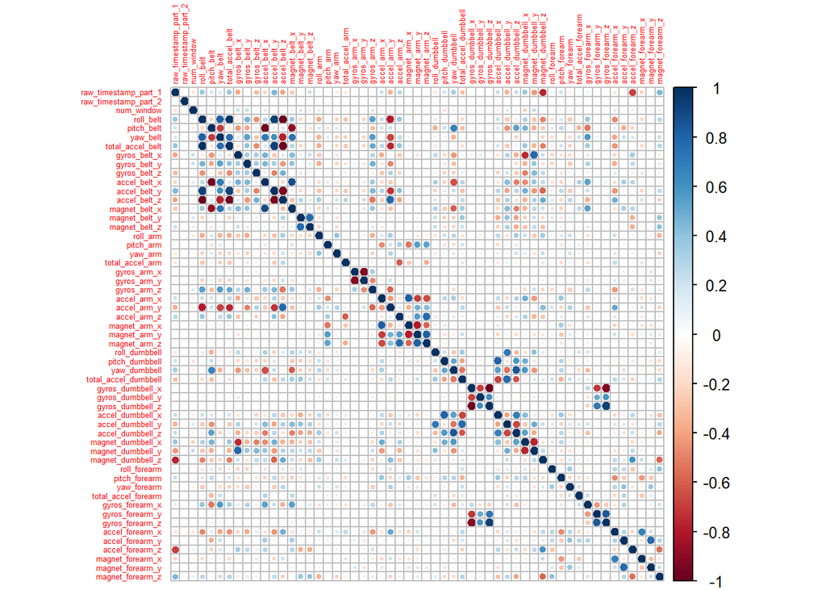